# IS-680 FINAL FALL’21 V_SAI_PRANAV.nb

```r
require(tidyverse)
```

```r
pac=read_csv(url('https://ygenc.github.io/lectures/data/pac_all_raw.csv'))
pac
```

| name | country | parent | total | dems | repubs | year |
| --- | --- | --- | --- | --- | --- | --- |
| ABB Daimler-Benz Transportation | Germany | Daimler-Benz AG | 15775 | 10775 | 5000 | 1998 |
| ABB Group | Switzerland | Asea Brown Boveri | 48500 | 19750 | 28750 | 1998 |
| AE Staley Manufacturing (Tate & Lyle) | UK | Tate & Lyle | 30500 | 3500 | 27000 | 1998 |
| AEGON USA (AEGON USA) | Netherlands | Aegon NV | 41700 | 10100 | 31600 | 1998 |
| Alcatel USA | France | Alcatel | 31000 | 8500 | 22500 | 1998 |
| Allied Domecq Spirits & Wine | UK | Allied Domecq | 39500 | 11000 | 28500 | 1998 |
| APL Ltd | Singapore | Neptune Orient Lines | 41983 | 18060 | 23923 | 1998 |
| Aqua-Chem Inc | France | Lyonnaise des Eaux-Dumez Group | 11800 | 1200 | 10600 | 1998 |
| Ares-Serono Inc | Switzerland | Serono SA | 6357 | 5857 | 500 | 1998 |
| Bacardi Corp | UK | Bacardi Ltd | 0 | 0 | 0 | 1998 |

[output cut: 990 more lines]

**Question 1** **A**

```r
summary(pac)
```

```
     name             country             parent              total              dems            repubs
 Length:2181        Length:2181        Length:2181        Min.   : -12500   Min.   : -4500   Min.   :-11000
 Class :character   Class :character   Class :character   1st Qu.:   6500   1st Qu.:  1900   1st Qu.:  3000
 Mode  :character   Mode  :character   Mode  :character   Median :  28000   Median : 10000   Median : 17050
                                                          Mean   :  80920   Mean   : 32708   Mean   : 48011
                                                          3rd Qu.:  96183   3rd Qu.: 35875   3rd Qu.: 54763
                                                          Max.   :1510897   Max.   :858223   Max.   :808750
                                                          NA's   :1         NA's   :2        NA's   :1
      year
 Min.   :1098
 1st Qu.:2006
 Median :2012
 Mean   :2010
 3rd Qu.:2016
 Max.   :2020
```

Looking at the summary we can identify that there are NA values in the total, dems, repubs columns of data frame which is the first issue.

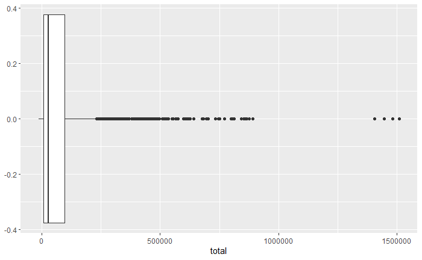

```r
ggplot(pac, aes(total)) +
  geom_boxplot()
```

Another issue is that there are outliers too in the ’total; column of the data set.

```r
pac %>%
  group_by(dems) %>%
  summarize(n = n())
```

| dems | n |
| --- | --- |
| -4500 | 1 |
| -4000 | 1 |
| -3000 | 1 |
| -1500 | 1 |
| -1000 | 1 |
| -500 | 3 |
| -250 | 1 |
| 0 | 390 |
| 1 | 1 |
| 200 | 1 |

[output cut: 641 more lines]

Another issue is that number of zeros in dems, total and repubs columns is more.

**B**

```r
sum(is.na(pac))
```

```
[1] 4
```

Aas we can see there are NA’s in the dataset.

```r
pac_no_na <- na.omit(pac)
```

The above chunk is to remove all the NA values in the data set and stores the data into new dataset.

```r
sum(is.na(pac_no_na))
```

```
[1] 0
```

There no NA’s now in dataset.

**Question 2** **A**

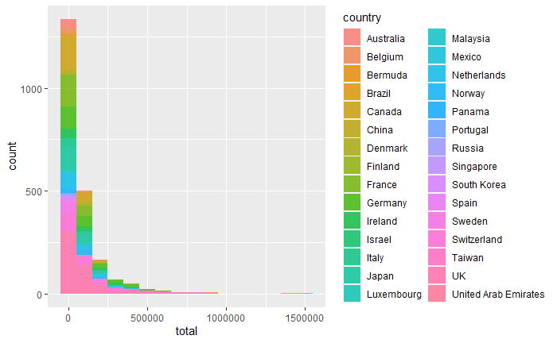

```r
ggplot(data = pac_no_na, mapping = aes(x = total, fill = country)) +
  geom_histogram(binwidth = 100000, alpha = 0.8)
```

As you cans see the graph the the distribution curve goes on decreasing as the value in the column increases.

**B**

```r
pac_smry <- pac_no_na %>%
              summarize(mean_tot = mean(total), st_dev = sd(total))
pac_smry
```

| mean_tot | st_dev |
| --- | --- |
| 80955.8 | 138217 |

Here in above chunk mean will give us the average value in the ‘total’ column and standard deviation will tell us if the data points are near to value 138217.

**C**

```r
pac_rpt <- pac_no_na %>%
            group_by(country) %>%
            summarize(total_contri = sum(total), mean_contri = mean(total))
pac_rpt
```

| country | total_contri | mean_contri |
| --- | --- | --- |
| Australia | 1287113 | 28602.511 |
| Belgium | 6233566 | 138523.689 |
| Bermuda | 1165132 | 166447.429 |
| Brazil | 810250 | 47661.765 |
| Canada | 6644438 | 31640.181 |
| China | 472029 | 36309.923 |
| Denmark | 3082519 | 102750.633 |
| Finland | 34200 | 34200.000 |
| France | 10425215 | 47822.087 |
| Germany | 23434340 | 110539.340 |

[output cut: 20 more lines]

From the above chunk you can see that the report above displays the total and the mean contribution for each country.

**Question 3**

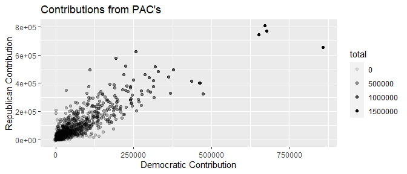

```r
pac_sct <- ggplot(pac, aes(x=dems,y=repubs, alpha = total)) +
                  geom_point()
pac_sct + labs(title = "Contributions from PAC's",
                   x="Democratic Contribution",y="Republican Contribution")
```

**Question 4** **A**

```r
plt <- pac_no_na %>%
            select(year, dems, repubs)
plt
```

| year | dems | repubs |
| --- | --- | --- |
| 1998 | 10775 | 5000 |
| 1998 | 19750 | 28750 |
| 1998 | 3500 | 27000 |
| 1998 | 10100 | 31600 |
| 1998 | 8500 | 22500 |
| 1998 | 11000 | 28500 |
| 1998 | 18060 | 23923 |
| 1998 | 1200 | 10600 |
| 1998 | 5857 | 500 |
| 1998 | 0 | 0 |

[output cut: 990 more lines]

```r
bar_plt <- pivot_longer(plt, -year, names_to="variable", values_to="value")
```

In the above chunk I have only selected the dems, repubs and year columns and stored them into a new data frame.Then used pivot longer in order to plot the bar plot. Pivot longer here will exclude the year column and take the rest of the two columns as variables.

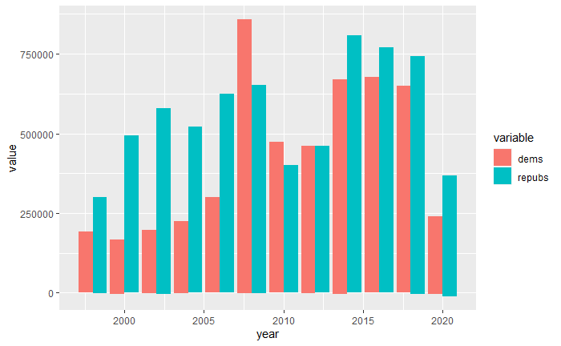

```r
ggplot(bar_plt,aes(x = year,y = value)) +
    geom_bar(aes(fill = variable),stat = "identity",position = "dodge")
```

As you can see int he graph above most of the times Republicans are the ones who were getting more contributions when compared to democrats over the time. Democrats got more contribution only in between the year 2007 to 2010.

**B**

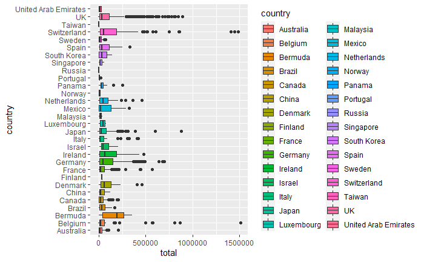

```r
pac_box<-ggplot(pac_no_na, aes(x=total, y=country, fill = country)) +
  geom_boxplot()
pac_box
```

From the box plot above you can see that the UK, Switzerland, Ireland, Germany, Bermuda etc. are the countries which have contributed more than other countries.

**Question 5** Which country has contributed more to Republicans ?

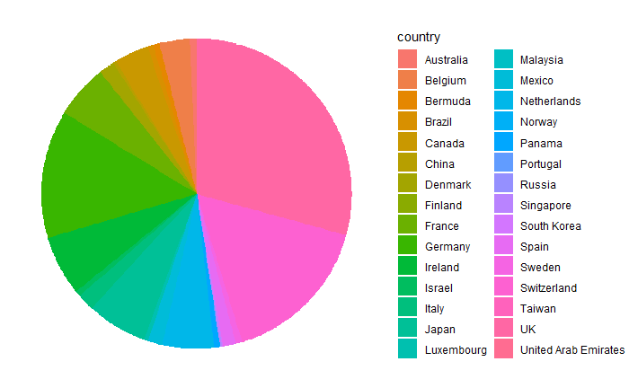

```r
ggplot(pac_no_na, aes(x="", y=repubs, fill=country)) +
  geom_bar(stat="identity", width=1) +
  coord_polar("y", start=0) +
  theme_void()
```

```r
NA
```

As I wanted to show something with pie plot in the above plot we can see that which country has contributed more to the republicans. UK, Switzerland and Germany are the countries we can say that has contributed more to the Republicans based on the data set.